# HackatonML

Dia5 Team 8

12/8/2021

### Joshua Jeyaratnam, Rita-Mathilda Kabro, Daniel Lévy

# Introduction

This dataset contains audio features of tracks for a certain user from Spotify.

Every Track is labeled in the column target: “1” means the user likes the track. “0” means he doesn’t like it.

This could be the learning task of your models.

Every observation corresponds to a track.

There is 16 columns in the dataset. 3 of them describe the track: track’s name, artist, and the target.

The other 13 columns are the audio features of a track: acousticness. danceability. duration_ms. energy. instrumentalness. key. liveness. loudness. mode. speechiness. tempo. time_signature. valence.

# Data Processing

```r
data=read.csv('/Users/daniel/Desktop/data.csv')
str(data)
```

```
## 'data.frame':    1817 obs. of  16 variables:
##  $ acousticness    : num  0.0102 0.199 0.0344 0.604 0.18 0.00479 0.0145 0.0202 0.0481 0.0572 ...
##  $ danceability    : num  0.833 0.743 0.838 0.494 0.678 0.804 0.739 0.266 0.603 0.525 ...
##  $ duration_ms     : num  204600 326933 185707 199413 392893 ...
##  $ energy          : num  0.434 0.359 0.412 0.338 0.561 0.56 0.472 0.348 0.944 0.855 ...
##  $ instrumentalness: num  2.19e-02 6.11e-03 2.34e-04 5.10e-01 5.12e-01 0.00 7.27e-06 6.64e-01 0.00 1.43e-02 ...
##  $ key             : int  2 1 2 5 5 8 1 10 11 5 ...
##  $ liveness        : num  0.165 0.137 0.159 0.0922 0.439 0.164 0.207 0.16 0.342 0.649 ...
##  $ loudness        : num  -8.79 -10.4 -7.15 -15.24 -11.65 ...
##  $ mode            : int  1 1 1 1 0 1 1 0 0 0 ...
##  $ speechiness     : num  0.431 0.0794 0.289 0.0261 0.0694 0.185 0.156 0.0371 0.347 0.0548 ...
##  $ tempo           : num  150.1 160.1 75 86.5 174 ...
##  $ time_signature  : int  4 4 4 4 4 4 4 4 4 3 ...
##  $ valence         : num  0.286 0.588 0.173 0.23 0.904 0.264 0.308 0.393 0.398 0.524 ...
##  $ target          : int  1 1 1 1 1 1 1 1 1 1 ...
##  $ song_title      : chr  "Mask Off" "Redbone" "Xanny Family" "Master Of None" ...
##  $ artist          : chr  "Future" "Childish Gambino" "Future" "Beach House" ...
```

```r
unique(data$mode)
```

```
## [1] 1 0
```

```r
unique(data$key)
```

```
##  [1]  2  1  5  8 10 11  0  9  6  4  7  3
```

```r
#unique(data$artist)
```

We choose to remove artist and song_title as mentioned above.

```r
data=data[1:14]
str(data)
```

```
## 'data.frame':    1817 obs. of  14 variables:
##  $ acousticness    : num  0.0102 0.199 0.0344 0.604 0.18 0.00479 0.0145 0.0202 0.0481 0.0572 ...
##  $ danceability    : num  0.833 0.743 0.838 0.494 0.678 0.804 0.739 0.266 0.603 0.525 ...
##  $ duration_ms     : num  204600 326933 185707 199413 392893 ...
##  $ energy          : num  0.434 0.359 0.412 0.338 0.561 0.56 0.472 0.348 0.944 0.855 ...
##  $ instrumentalness: num  2.19e-02 6.11e-03 2.34e-04 5.10e-01 5.12e-01 0.00 7.27e-06 6.64e-01 0.00 1.43e-02 ...
##  $ key             : int  2 1 2 5 5 8 1 10 11 5 ...
##  $ liveness        : num  0.165 0.137 0.159 0.0922 0.439 0.164 0.207 0.16 0.342 0.649 ...
##  $ loudness        : num  -8.79 -10.4 -7.15 -15.24 -11.65 ...
##  $ mode            : int  1 1 1 1 0 1 1 0 0 0 ...
##  $ speechiness     : num  0.431 0.0794 0.289 0.0261 0.0694 0.185 0.156 0.0371 0.347 0.0548 ...
##  $ tempo           : num  150.1 160.1 75 86.5 174 ...
##  $ time_signature  : int  4 4 4 4 4 4 4 4 4 3 ...
##  $ valence         : num  0.286 0.588 0.173 0.23 0.904 0.264 0.308 0.393 0.398 0.524 ...
##  $ target          : int  1 1 1 1 1 1 1 1 1 1 ...
```

## Visualization

Some visualization to understand how the data are represented in the dataset.

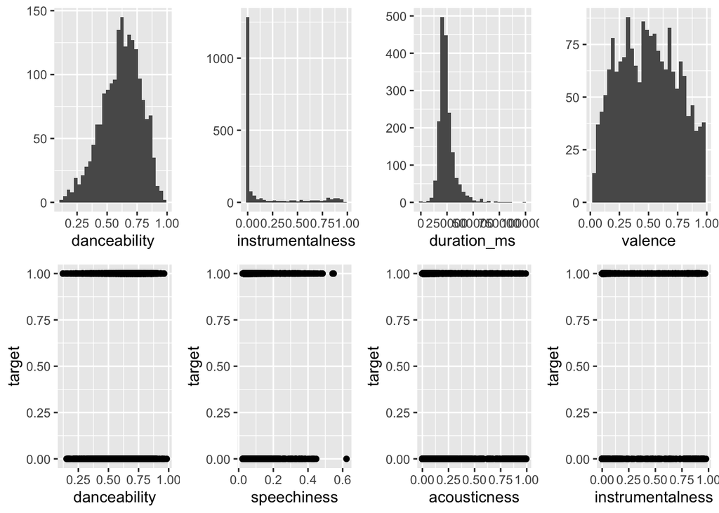

```r
library(ggplot2)
library(gridExtra)
P1=qplot(danceability,data=data ,geom="histogram")
P2=qplot(instrumentalness,data=data,geom="histogram")
P3=qplot(duration_ms,data=data ,geom="histogram")
P4=qplot(valence,data=data ,geom="histogram")
P5=qplot(loudness,data=data, geom="histogram")
P5=qplot(danceability,target,data=data)
P6=qplot(speechiness,target,data=data)
P7=qplot(acousticness,target,data=data)
P8=qplot(instrumentalness,target,data=data)
grid.arrange(P1,P2,P3,P4,P5,P6,P7,P8, ncol=4, nrow = 2)
```

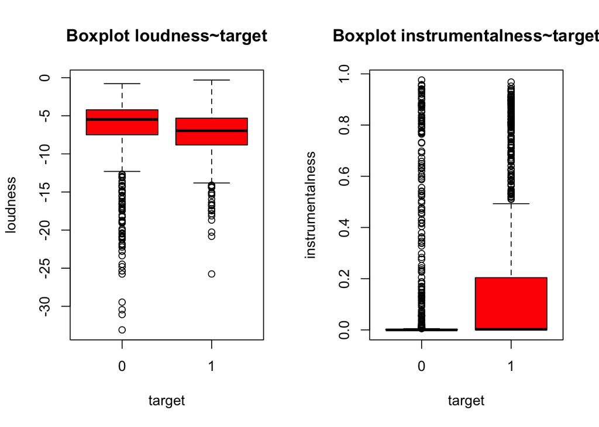

```r
par(mfrow=c(1,2))
boxplot( loudness~target, data=data,col = "red",main="Boxplot loudness~target")
boxplot( instrumentalness~target, data=data,col = "red",main="Boxplot instrumentalness~target")
```

```r
par(mfrow=c(1,1))
```

## Correlation Matrix

Very important visualization to understand features and target correlation. A correlation matrix is a table which displays the correlation coefficients for different variables. The matrix depicts the correlation between all the possible pairs of values in a table. It is a powerful tool to summarize a large dataset and to identify and visualize patterns in the given data. Strong relationship when the coefficent is near -1 or 1 Weak relationship around 0

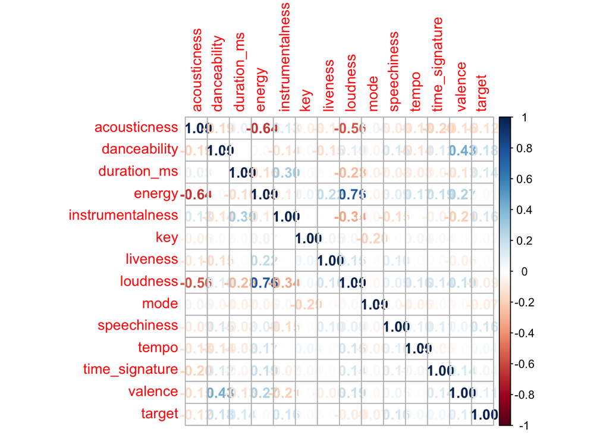

```r
library(corrplot)
M=cor(data)
corrplot(M, method="number")
```

```r
cor(data[ , colnames(data) !="target"], data$target)
```

```
##                         [,1]
## acousticness     -0.12346127
## danceability      0.18144238
## duration_ms       0.13827328
## energy            0.02023264
## instrumentalness  0.15592349
## key               0.02170962
## liveness          0.01127967
## loudness         -0.08965859
## mode             -0.07134846
## speechiness       0.15811384
## tempo             0.03525887
## time_signature    0.04210961
## valence           0.10806455
```

## Spliting training and test set

We choose a ratio of 75% to split into a train and test set

```r
library(caTools)
set.seed(123)
split = sample.split(data$target, SplitRatio = 0.75)
training_set = subset(data, split == TRUE)
test_set = subset(data, split == FALSE)
```

## Scaling the data

```r
training_set_scaled = subset(data, split == TRUE)
test_set_scaled = subset(data, split == FALSE)

training_set_scaled[,1:5]=as.data.frame(scale(training_set_scaled[,1:5]))
test_set_scaled[,1:5]=as.data.frame(scale(test_set_scaled[,1:5]))
training_set_scaled[,7:13]=as.data.frame(scale(training_set_scaled[,7:13]))
test_set_scaled[,7:13]=as.data.frame(scale(test_set_scaled[,7:13]))
```

Scaling duration_ms

```r
#training_set_scaled$duration_ms=scale(training_set$duration_ms)
#test_set_scaled$duration_ms=scale(test_set$duration_ms)
```

# Machine Learning Models

We tried several models seen during Practical Works sessions in order to find the best accuracy. As it is a classification problem we focused on the best classification models such as : -Random Forest (and bagging) -Trees -Boosting Trees -Logistic Regression We choose to begin with Random Forest known as a powerful and adaptative algorithm.

## Accuracy function

function to compute accuracy of the models. % of good predictions.

```r
accuracy = function(pred,test){
  mean(pred == test)
}
library(caret)
```

loading caret package to compute confusion matrix of the models

## Machine Learning Models

We tried several models seen during Practical Works sessions in order to find the best accuracy. As it is a classification problem we focused on the best classification models such as : -Random Forest (and bagging) -Trees -Boosting Trees -Logistic Regression We choose to begin with Random Forest known as a powerful and adaptative algorithm.

### Random Forest

Parameters: RF: mtry = number of features square root. Bagging: mtry = number of features-1 We saw a better performance with Random Forest

```r
#-key-time_signature-mode
library(randomForest)
modelTestRF = randomForest(target ~ ., data = training_set, mtry = sqrt(14),importance = TRUE, ntrees = 8000)
predi_test = predict(modelTestRF, newdata = test_set)
predicted_test = ifelse(predi_test> 0.5, 1, 0)
accRF = accuracy(predicted_test, test_set$target)
accRF
```

```
## [1] 0.7692308
```

```r
#0.7824176
confusionmatrix = table(predicted_test, test_set$target)
confusionmatrix
```

```
##
## predicted_test   0   1
##              0 170  49
##              1  56 180
```

### RPART

```r
library(rpart)
modelTestRP = rpart(target ~ ., data = data)
predi_test = predict(modelTestRP, newdata = test_set)
predicted_test = ifelse(predi_test> 0.5, 1, 0)
accRPART= accuracy(predicted_test, test_set$target)
accRPART
```

```
## [1] 0.7648352
```

```r
#[1] 0.7648352
confusionmatrix = table(predicted_test, test_set$target)
confusionmatrix
```

```
##
## predicted_test   0   1
##              0 173  54
##              1  53 175
```

### GBM

At the beginning we tried to compute the model with n.trees=500,interaction.depth=4,shrinkage=0.01 and we worked to extend the depth of the model through the parameters. We obtained a nice performance with n.trees = 8000, interaction.depth = 10, shrinkage = 0.009

Test on Parameters:

```r
library(gbm)
modelTestGBM = gbm(target ~ ., data = training_set, distribution = "gaussian",
                   n.trees=500,interaction.depth=4,shrinkage=0.01)

predi_test = predict(modelTestGBM, newdata = test_set)
```

```
## Using 500 trees...
```

```r
predicted_test = ifelse(predi_test> 0.5, 1, 0)
accuracy(predicted_test, test_set$target)
```

```
## [1] 0.7648352
```

```r
#0.7582418
```

Best parameters:

```r
modelTestGBM = gbm(target ~ ., data = training_set, distribution = "gaussian",
                   n.trees = 8000, interaction.depth = 10, shrinkage = 0.009)

predi_test = predict(modelTestGBM, newdata = test_set)
```

```
## Using 8000 trees...
```

```r
predicted_test = ifelse(predi_test> 0.5, 1, 0)
accGBM = accuracy(predicted_test, test_set$target)
accGBM
```

```
## [1] 0.7868132
```

```r
#[1] 0.7648352 without scaling
#[1] 0.5340659 after scaling
confusionmatrix = table(predicted_test, test_set$target)
confusionmatrix
```

```
##
## predicted_test   0   1
##              0 173  44
##              1  53 185
```

### GLM

```r
modelTestGLM = glm(target ~ ., family='binomial', data=training_set)
predi_test = predict(modelTestGLM, test_set)
predicted_test = ifelse(predi_test >= 0.5, 1, 0)
accGLM = accuracy(predicted_test, test_set$target)
accGLM
```

```
## [1] 0.6285714
```

```r
#[1] 0.6285714 without scaling
#[1] 0.621978 after scaling
confusionmatrix = table(predicted_test, test_set$target)
confusionmatrix
```

```
##
## predicted_test   0   1
##              0 194 137
##              1  32  92
```

### Accuracy Comparaison

```r
c('RF',accRF)
```

```
## [1] "RF"                "0.769230769230769"
```

```r
c("RPART",accRPART)
```

```
## [1] "RPART"             "0.764835164835165"
```

```r
c("GBM",accGBM)
```

```
## [1] "GBM"               "0.786813186813187"
```

```r
c("GLM",accGLM)
```

```
## [1] "GLM"               "0.628571428571429"
```

At first we saw a better accuracy with Random Forest and Boosting Tree but after trying some submissions we noticed a better performance with Boosting Tree model.

We try to compute the Best Model with scaled data.

```r
library(gbm)
modelTestGBM_Scaled = gbm(target ~ ., data = training_set_scaled, distribution = "gaussian",
                   n.trees = 8000, interaction.depth = 10, shrinkage = 0.009)

predi_test = predict(modelTestGBM_Scaled, newdata = test_set)
```

```
## Using 8000 trees...
```

```r
predicted_test = ifelse(predi_test> 0.5, 1, 0)
accGBM_scaled = accuracy(predicted_test, test_set$target)
accGBM_scaled
```

```
## [1] 0.5032967
```

```r
#[1] 0.7648352 without scaling
#[1] 0.5340659 after scaling
confusionmatrix = table(predicted_test, test_set$target)
confusionmatrix
```

```
##
## predicted_test   0   1
##              1 226 229
```

```r
c("GBM scaled",accGBM_scaled)
```

```
## [1] "GBM scaled"        "0.503296703296703"
```

```r
c("GBM",accGBM)
```

```
## [1] "GBM"               "0.786813186813187"
```

# Conclusion

We have shown you how to work on a dataset in order to be able to predict here in our case if the Spotify user will like the song or not. We have done several classification methods to have a range of models, in order to take the best model we compared the accuracy of the models. As we have seen in class, boosting is one of the most powerful classification methods. We have chosen this model and we have optimized it by changing the different parameters. We came first during the Hackathon so we can be satisfied with our work but we can still go further to optimize the model taking into account the authors as mentioned in the beginning of this report. This experience was very instructive and challenging for all of us. We would like to thank Mr. Ghassany and Mrs. SLIMANI for the quality of the teaching provided.

# Performing the best model for the submission

```r
data_ToPredict=read.csv('/Users/daniel/Desktop/test.csv')

model = gbm(target ~ ., data = training_set, distribution = "gaussian", n.trees = 8000, interaction.depth = 10, shrinkage = 0.009)
#model = randomForest(target ~ ., data = data, mtry = 5,importance = TRUE, ntrees = 8000)

predi=predict(model, newdata = data_ToPredict)
```

```
## Using 8000 trees...
```

```r
predicted = ifelse(predi >= 0.5, 1,0)
to_be_submitted = data.frame(id=rownames(data_ToPredict), target=predicted)
write.csv(to_be_submitted , file = "/Users/daniel/Desktop/HACKATON_PRED.csv", row.names = F)
FINAL_PREDICTIONS=read.csv('/Users/daniel/Downloads/test8_5.csv')
FINAL_PREDICTIONS
```

[output not shown]

[output cut: 186 more lines]